# IE360 Homework 3

## Intro

In this homework, the electricity consumption data was extracted from EPIAS for comparing different models. After visualising the data, deseasoning and detrending applications were used in order to make the data as stationary as possible. Lastly, different arima models were tried and compared in terms of their information criteria.

```r
library(readxl)
library(data.table)
elec_cons <- read_excel("C:\\Users\\Ezgi-Pc\\Desktop\\elec_cons.xlsx")
names(elec_cons) <- c("Date", "Hour", "Consumption")
elec_cons <- data.table(elec_cons)
```

## Question 1

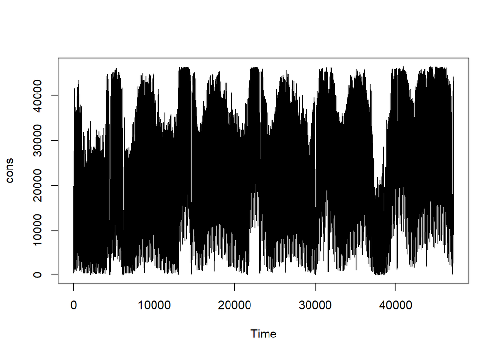

```r
cons <- elec_cons[,3]
ts.plot(cons)
```

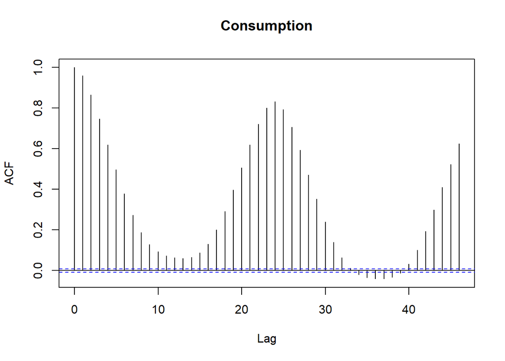

```r
acf(elec_cons[,3])
```

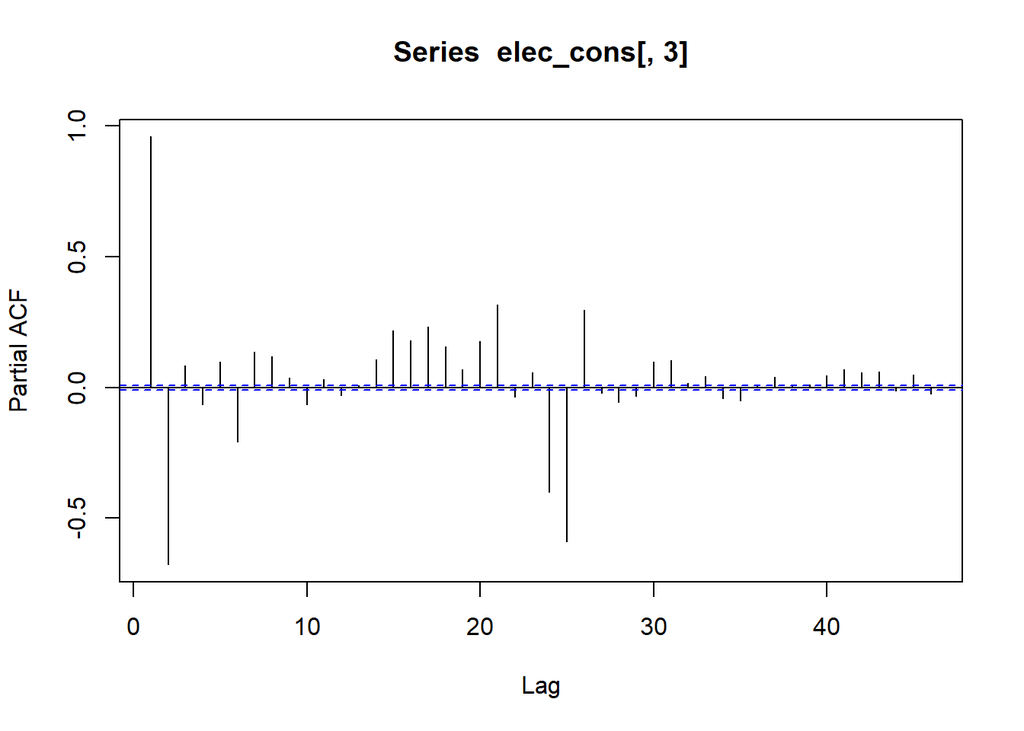

```r
pacf(elec_cons[,3])
```

As seen in the plot and the acf graph of the data, there is a strong seasonality. However, there is almost no trend, maybe a slightly increasing trend that is kind of negligible. In addition, there is a decrease in electricity consumption during a part of 2020, probably due to the COVID-19 pandemic and the fact that people worked from home for a long time. Since workplaces are the places where the electricity consumption is pretty high, the fact that they did not use that much electricity during those months decreased the consumption significantly.

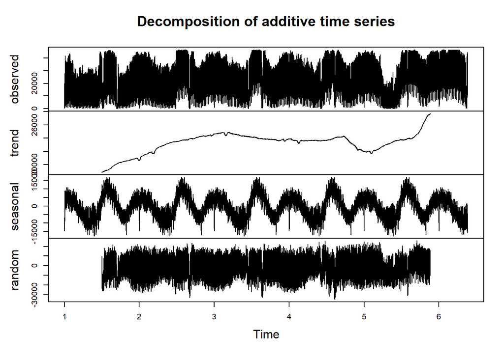

```r
cons_hourly <- ts(cons, frequency = 8766)
cons_h_dec <- decompose(cons_hourly, type = "additive")
plot(cons_h_dec)
```

When the data (hourly level) is decomposed, the trend and the seasonality factor are quite visible. As mentioned above, there is a slightly upwards trend and a strong seasonality.

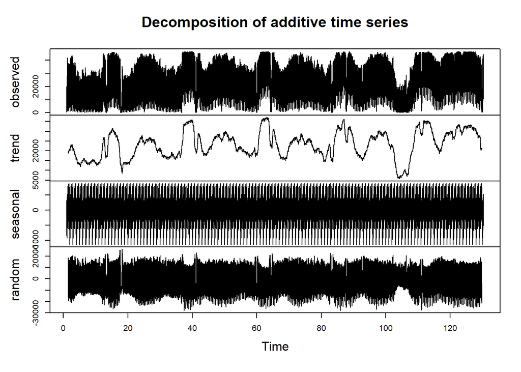

```r
cons_daily <- ts(cons, frequency = 365)
cons_d_dec <- decompose(cons_daily, type = "additive")
plot(cons_d_dec)
```

When the data (daily level) is decomposed, the trend component shows some seasonality and the seasonality component has a much higher frequence.

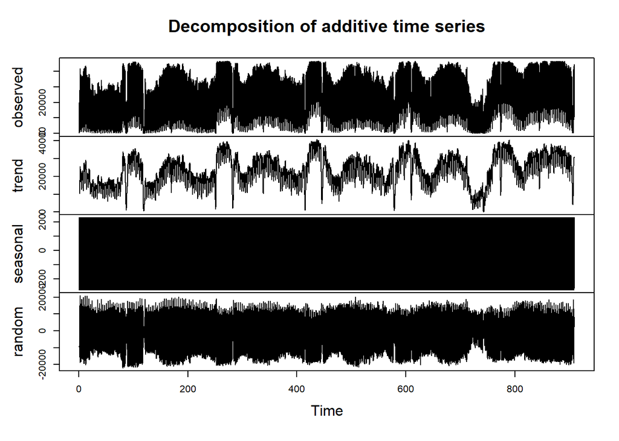

```r
cons_weekly <- ts(cons, frequency = 52)
cons_w_dec <- decompose(cons_weekly, type = "additive")
plot(cons_w_dec)
```

When the data (weekly level) is decomposed, the trend component is thicker and has a seasonality in it again. However, there is not much to say about the seasonality component as the frequency is so high that it is not possible to see the graph properly, it is all black.

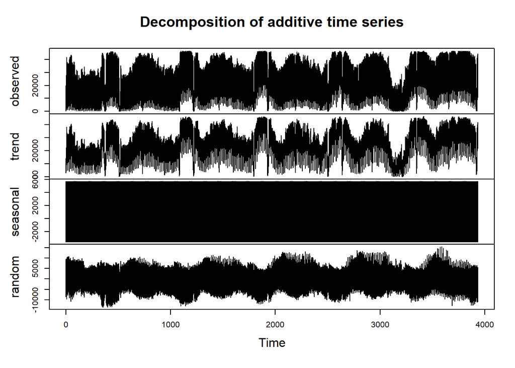

```r
cons_monthly <- ts(cons, frequency = 12)
cons_m_dec <- decompose(cons_monthly, type = "additive")
plot(cons_m_dec)
```

As one would predict, when the data (monthly level) is decomposed, one would find a thicker trend component that has seasonality in it and a black seasonality component with a very high frequency.

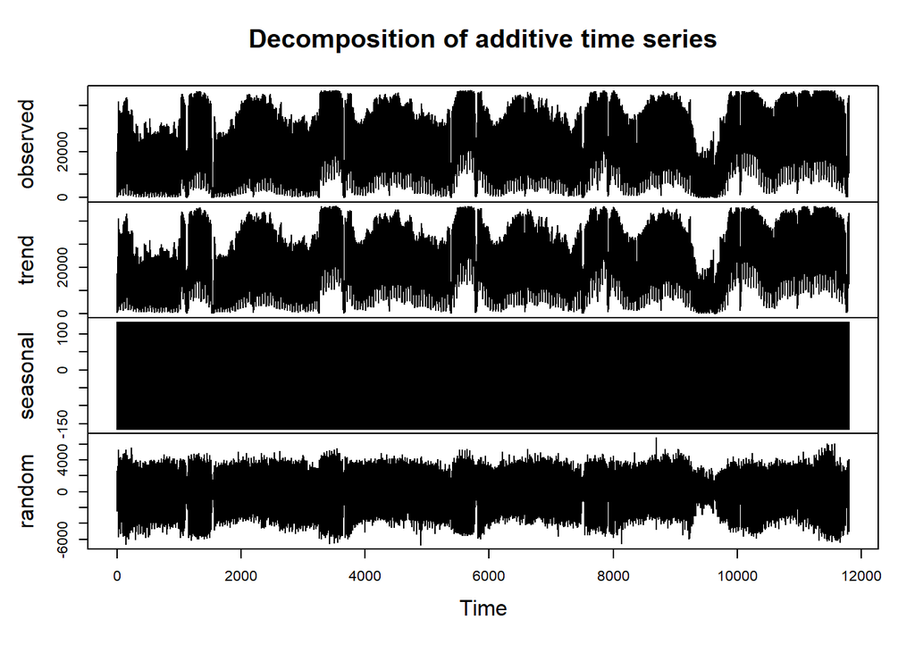

```r
cons_quarterly <- ts(cons, frequency = 4)
cons_q_dec <- decompose(cons_quarterly, type = "additive")
plot(cons_q_dec)
```

Lastly, when the data is decomposed on quarterly level, the same changes as before occur and the trend component gets even thicker, while the seasonality component is all black.

Since the directions of the components are clear, the decoposition of yearly level data was not included.

## Question 2

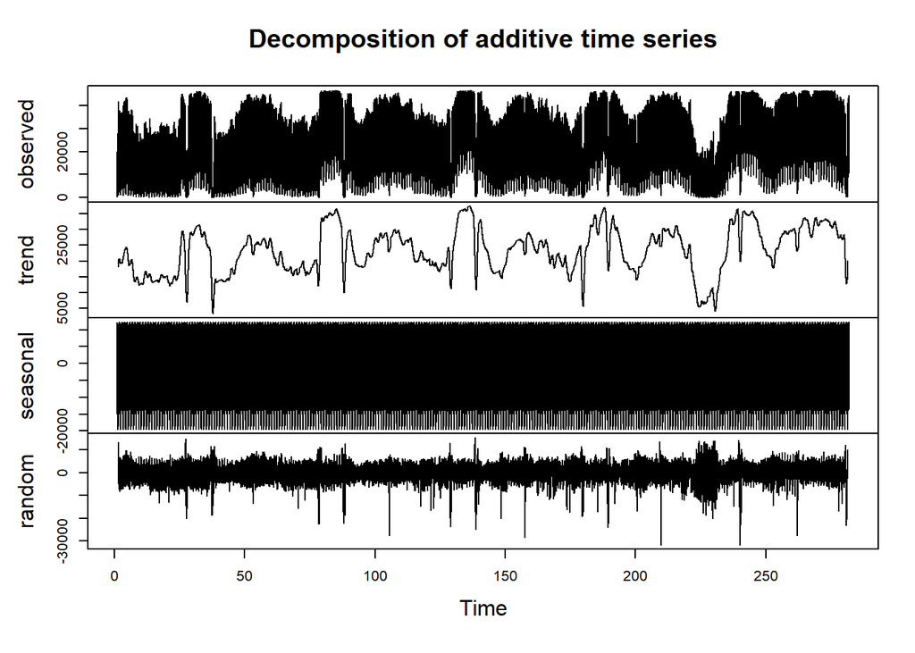

```r
cons_ts <- ts(cons, frequency = 168)
cons_dec <- decompose(cons_ts, type = "additive")
plot(cons_dec)
```

When the data is decomposed according to the pattern of 168 hours, a plot similar to daily level decomposition plot is observed. Here, the random component seems to have constant mean but a seasonality can somewhat be observed. Additionally, some exceptions are also observed as time goes. Probably, these exceptions belong to the days of national or religional holidays. These exceptions were not this possible to observe in the above plots of question 1.

## Question 3

[figure not shown]

```r
deseas_cons <- cons_ts - cons_dec$seasonal
detr_cons <- deseas_cons - cons_dec$trend
plot(detr_cons)
```

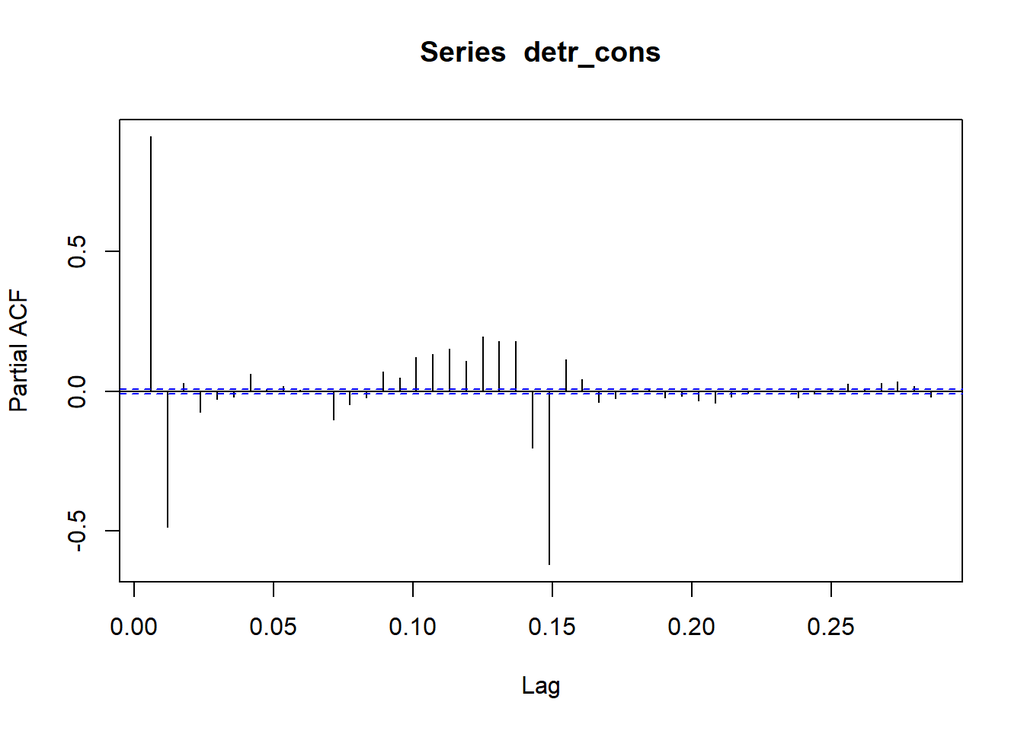

```r
pacf(detr_cons, na.action = na.pass, lag.max = 48)
```

```r
arima(detr_cons, order = c(1,0,0))
```

```
##
## Call:
## arima(x = detr_cons, order = c(1, 0, 0))
##
## Coefficients:
##          ar1  intercept
##       0.9120    -3.0750
## s.e.  0.0019    84.7471
##
## sigma^2 estimated as 2617167:  log likelihood = -414317,  aic = 828640
```

Here, the AIC value is 828640.

```r
arima(detr_cons, order = c(2,0,0))
```

```
##
## Call:
## arima(x = detr_cons, order = c(2, 0, 0))
##
## Coefficients:
##         ar1      ar2  intercept
##       1.355  -0.4859    -3.0779
## s.e.  0.004   0.0040    49.8142
##
## sigma^2 estimated as 2e+06:  log likelihood = -407985.9,  aic = 815979.9
```

Here, the AIC value is 815979.9. Increasing the lag made the model better as the AIC value decreased.

Now, the lag of 24, which was suggested by the pacf graph, is tried.

```r
arima(detr_cons, order = c(24,0,0))
```

```
##
## Call:
## arima(x = detr_cons, order = c(24, 0, 0))
##
## Coefficients:
##          ar1      ar2     ar3      ar4     ar5      ar6     ar7      ar8
##       1.2494  -0.4948  0.1333  -0.0737  0.0828  -0.1151  0.0691  -0.0429
## s.e.  0.0045   0.0071  0.0074   0.0074  0.0074   0.0074  0.0074   0.0074
##          ar9     ar10    ar11     ar12    ar13     ar14    ar15     ar16
##       0.0526  -0.0884  0.1248  -0.0709  0.0671  -0.1141  0.0748  -0.0620
## s.e.  0.0074   0.0074  0.0074   0.0074  0.0074   0.0074  0.0074   0.0074
##         ar17     ar18    ar19     ar20    ar21     ar22    ar23     ar24
##       0.0385  -0.0628  0.1088  -0.0859  0.0773  -0.1406  0.4259  -0.2032
## s.e.  0.0074   0.0074  0.0074   0.0074  0.0074   0.0074  0.0071   0.0045
##       intercept
##         -2.9959
## s.e.   114.4938
##
## sigma^2 estimated as 1558262:  log likelihood = -402124.1,  aic = 804300.2
```

## Question 4

As the data is deseasonalised and detrended in question 3, detr_cons is used in this question, too.

[figure not shown]

```r
acf(detr_cons, na.action = na.pass, lag.max = 192)
```

The remaining seasonality of the data is visible through the acf graph. Here, apart from the immediate lags, the lags of 24 and 168 stand out as they have higher spikes than the rest. However, due to a problem in R, I could not get MA(168) model but as the spike of lag 24 beats lag 168, MA(24) model is tried.

```r
arima(detr_cons, order = c(0,0,1))
```

```
##
## Call:
## arima(x = detr_cons, order = c(0, 0, 1))
##
## Coefficients:
##          ma1  intercept
##       0.8692    -3.0818
## s.e.  0.0016    20.0400
##
## sigma^2 estimated as 5407447:  log likelihood = -431384.9,  aic = 862775.8
```

To begin with, MA(1) model was tried. The AIC value is 862775.8

```r
arima(detr_cons, order = c(0,0,24))
```

```
##
## Call:
## arima(x = detr_cons, order = c(0, 0, 24))
##
## Coefficients:
##          ma1     ma2     ma3     ma4     ma5     ma6     ma7     ma8     ma9
##       1.3272  1.3428  1.2933  1.1955  1.1104  0.9888  0.8612  0.7294  0.6135
## s.e.  0.0045  0.0069  0.0087  0.0101  0.0111  0.0120  0.0128  0.0132  0.0134
##         ma10    ma11    ma12    ma13    ma14    ma15     ma16     ma17     ma18
##       0.4767  0.3995  0.3343  0.2844  0.1964  0.0953  -0.0320  -0.1645  -0.3115
## s.e.  0.0131  0.0125  0.0121  0.0122  0.0125  0.0128   0.0131   0.0132   0.0130
##          ma19     ma20     ma21     ma22     ma23     ma24  intercept
##       -0.4187  -0.5220  -0.6054  -0.7105  -0.7147  -0.2154    -3.0603
## s.e.   0.0121   0.0107   0.0092   0.0072   0.0060   0.0048    46.2360
##
## sigma^2 estimated as 1375057:  log likelihood = -399183.7,  aic = 798419.4
```

Here, a significant improvement is observed as the AIC value decreased to 798419.4

## Question 5

Checking the acf and pacf graphs again,

[figure not shown]

```r
acf(detr_cons, na.action = na.pass, lag.max = 192)
```

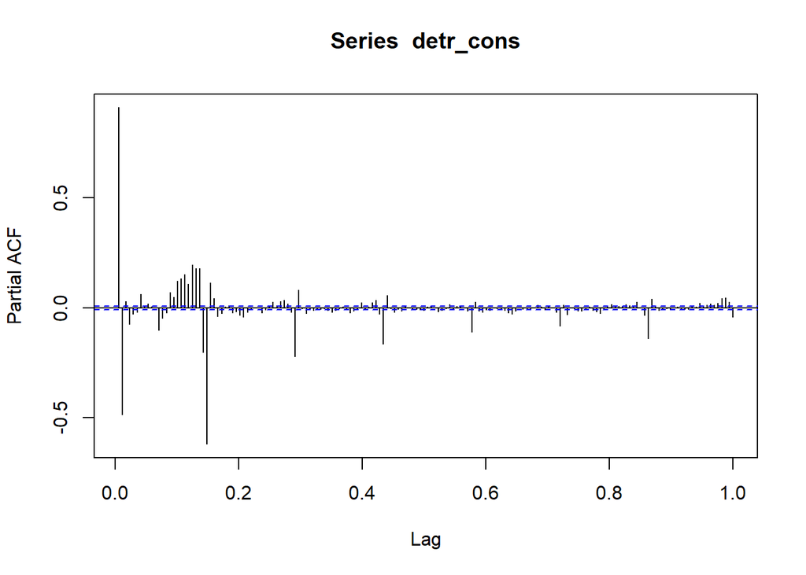

```r
pacf(detr_cons, na.action = na.pass, lag.max =168)
```

## Conclusion

Electricity consumption is important to any country as the life of almost every sectors and households is dependent on the electricity and the countries must be able to meet the demand and produce accordingly. In this homework, an attempt to analyse the data and fit the appropriate ARIMA model was made. As mentioned above, due to a reason that I do not know currently, forecasting and examining the forecasting was not possible.